# Homework1

2026-02-23

# Question 1

I am going to add packages as needed, allows me to keep better track of questions and solving procedures.

```r
library(glmnet)
library(dplyr)
```

### 1) Working Directory

```r
setwd("/Users/karolinawiesiolek/Desktop/Mailman Spring 2026/DSII/HW1/Homework_1")

# sanity check: shows what R thinks the folder is
getwd()
```

```
## [1] "/Users/karolinawiesiolek/Desktop/Mailman Spring 2026/DSII/HW1/Homework_1"
```

```r
# sanity check: shows what files R sees inside this folder
list.files()
```

```
## [1] "dictionary.txt"       "Homework_1.html"      "Homework_1.Rmd"
## [4] "Homework_1.Rproj"     "housing_test.csv"     "housing_training.csv"
## [7] "README.md"
```

**Explanation** - `setwd(...)` tells R “this is the folder where my files live.” - `list.files()` is your fastest way to confirm the exact filenames (spaces, underscores, “(1)”, etc.).

### 2) Read training + test data (robust to filename variations)

This chunk tries to find the train/test/dictionary files even if they have slightly different names (like “training (1).csv”).

```r
# --- Helper function: find a file by keyword pattern ---
pick_file <- function(pattern) {
  f <- list.files(pattern = pattern, ignore.case = TRUE)
  if (length(f) == 0) stop("Could not find file matching pattern: ", pattern)
  f[1]  # take the first match
}

train_file <- pick_file("train|training")
test_file  <- pick_file("test")
dict_file  <- pick_file("dict|dictionary")

train_raw <- read.csv(train_file, stringsAsFactors = FALSE, check.names = FALSE)
test_raw  <- read.csv(test_file,  stringsAsFactors = FALSE, check.names = FALSE)

dim(train_raw)
```

```
## [1] 1440   26
```

```r
dim(test_raw)
```

```
## [1] 959  26
```

```r
names(train_raw)[1:10]
```

```
##  [1] "Gr_Liv_Area"     "First_Flr_SF"    "Second_Flr_SF"   "Total_Bsmt_SF"
##  [5] "Low_Qual_Fin_SF" "Wood_Deck_SF"    "Open_Porch_SF"   "Bsmt_Unf_SF"
##  [9] "Mas_Vnr_Area"    "Garage_Cars"
```

**Explanation** - `pick_file()` searches your folder using a regex pattern. - `read.csv(..., check.names = FALSE)` prevents R from silently changing column names (important because your response is `"Sale price"` with a space). - `stringsAsFactors = FALSE` keeps character columns as character (we’ll handle dummy coding ourselves).

### 3) Standardize the response column name

Your homework says the response column is `"Sale price"`, but sometimes it appears as `"Sale_Price"` or `"SalePrice"`. This code detects it and renames it to `SalePrice` in both train/test.

```r
resp_candidates <- c("Sale price", "Sale_Price", "SalePrice", "sale_price", "Sale Price")

resp_train <- resp_candidates[resp_candidates %in% names(train_raw)][1]
resp_test  <- resp_candidates[resp_candidates %in% names(test_raw)][1]

stopifnot(!is.na(resp_train), !is.na(resp_test))

train_raw <- train_raw %>% rename(SalePrice = all_of(resp_train))
test_raw  <- test_raw  %>% rename(SalePrice = all_of(resp_test))

summary(train_raw$SalePrice)
```

```
##    Min. 1st Qu.  Median    Mean 3rd Qu.    Max.
##   52000  130000  159000  177568  207000  755000
```

**Explanation** - We search for likely spellings of the response column. - `stopifnot(...)` immediately stops with an error if the response column wasn’t found (better than silently running wrong code). - Renaming to `SalePrice` makes everything consistent.

## 4) Build the `x` matrix and `y` vector for glmnet

`glmnet` does **not** take a data frame with factors directly. It wants: - `x`: numeric matrix (including dummy variables for categories) - `y`: numeric response vector

`model.matrix()` does the dummy encoding for you.

```r
# model.matrix creates dummy variables for factors/characters automatically.
# We remove the intercept column because glmnet includes an intercept by default.
x_train <- model.matrix(SalePrice ~ ., data = train_raw)[, -1]
y_train <- train_raw$SalePrice

x_test  <- model.matrix(SalePrice ~ ., data = test_raw)[, -1]
y_test  <- test_raw$SalePrice

dim(x_train)
```

```
## [1] 1440   39
```

```r
dim(x_test)
```

```
## [1] 959  39
```

**Explanation** - `SalePrice ~ .` means “use every other column as a predictor.” - `[, -1]` drops the intercept column. - Dummy encoding is crucial: categorical variables become 0/1 columns.

## 5) Fit LASSO with 10-fold CV and get tuning parameter

Lasso is `alpha = 1`.

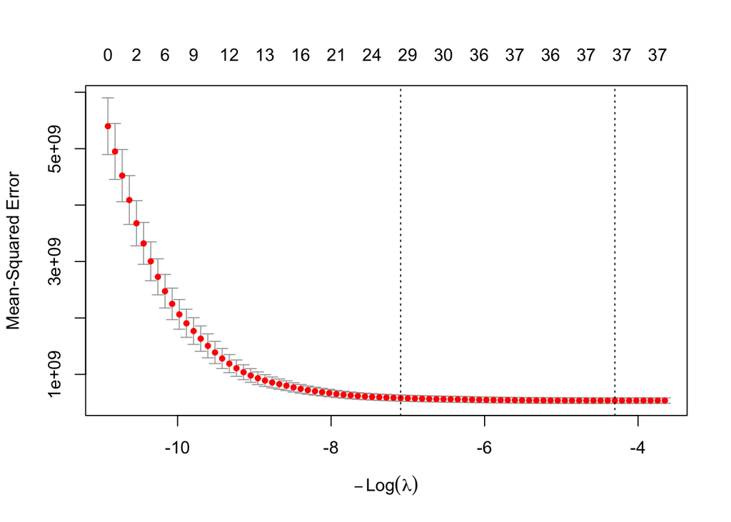

```r
set.seed(2026)  # makes CV folds reproducible

cv_lasso <- cv.glmnet(
  x = x_train,
  y = y_train,
  alpha = 1,       # alpha=1 => LASSO
  nfolds = 10,     # 10-fold cross-validation
  standardize = TRUE  # default TRUE; keeps predictors on comparable scales
)

# Plot CV curve
plot(cv_lasso)
```

```r
lambda_min <- cv_lasso$lambda.min  # lambda with minimum CV error
lambda_1se <- cv_lasso$lambda.1se  # 1SE rule lambda (more regularized)

lambda_min
```

```
## [1] 73.87226
```

```r
lambda_1se
```

```
## [1] 1203.934
```

**Explanation** - `cv.glmnet()` fits many lasso models across a sequence of λ values and evaluates them by CV. - `lambda.min` = best CV performance (lowest mean CV error). - `lambda.1se` = simplest model whose CV error is within **1 standard error** of the minimum (tends to select fewer predictors).

## 6) Test error (RMSE) at λ_min (and optionally λ_1se)

The homework asks for “test error.” In regression we usually report RMSE.

```r
rmse <- function(pred, truth) sqrt(mean((pred - truth)^2))

# Predictions on test set
pred_test_min <- as.numeric(predict(cv_lasso, newx = x_test, s = "lambda.min"))
pred_test_1se <- as.numeric(predict(cv_lasso, newx = x_test, s = "lambda.1se"))

test_rmse_min <- rmse(pred_test_min, y_test)
test_rmse_1se <- rmse(pred_test_1se, y_test)

test_rmse_min
```

```
## [1] 20955.73
```

```r
test_rmse_1se
```

```
## [1] 20707.31
```

**Explanation** - `predict(..., s="lambda.min")` uses the model tuned by CV and predicts test outcomes. - RMSE is in the same units as the outcome (`SalePrice`), so it’s easy to interpret.

> If your instructor expects MSE instead of RMSE, just square the RMSE or compute mean((pred-truth)^2).

## 7) How many predictors are included with the 1SE rule?

We count how many coefficients are non-zero at `lambda.1se`.  
We do **not** count the intercept.

```r
coef_1se <- coef(cv_lasso, s = "lambda.1se")  # sparse matrix of coefficients

# Count non-zero coefficients excluding intercept (first row)
n_predictors_1se <- sum(coef_1se[-1, 1] != 0)

n_predictors_1se
```

```
## [1] 27
```

**Explanation** - Lasso sets many coefficients exactly to 0. - Non-zero coefficients correspond to “selected predictors.” - `coef_1se[-1, ]` removes the intercept row before counting.

## 8) Final “report” lines for Part (a)

This prints exactly what you need to paste into your write-up.

```r
cat("Part (a) results:\n")
```

```
## Part (a) results:
```

```r
cat("Selected tuning parameter (lambda.min):", lambda_min, "\n")
```

```
## Selected tuning parameter (lambda.min): 73.87226
```

```r
cat("Test RMSE at lambda.min:", test_rmse_min, "\n\n")
```

```
## Test RMSE at lambda.min: 20955.73
```

```r
cat("1SE rule lambda (lambda.1se):", lambda_1se, "\n")
```

```
## 1SE rule lambda (lambda.1se): 1203.934
```

```r
cat("Test RMSE at lambda.1se:", test_rmse_1se, "\n")
```

```
## Test RMSE at lambda.1se: 20707.31
```

```r
cat("Number of predictors (nonzero) at lambda.1se:", n_predictors_1se, "\n")
```

```
## Number of predictors (nonzero) at lambda.1se: 27
```

## QUESTION 2